# Model 3: Cross-Wave Stability (MIDUS 2 / MIDUS 3)

# About this script

**Preregistered analysis (main text; RQ3).** Joint models of individual stability across MIDUS 2 and MIDUS 3 in (3a) average daily sleep duration and (3b) day-to-day sleep variability. Both are unconditional-means models (plus the `weekend` control retained in all models) fit to the participants in the full-time, standard-shift samples of both waves. Run the MIDUS 2 and MIDUS 3 structuring scripts first.

Both models use 4000 iterations (2000 warmup) and `adapt_delta = 0.99`. An earlier version of Model 3a had bulk ESS < 1000 at the preregistered 2000 iterations, so its iterations were doubled.

# Packages, data, and helper functions

```r
library(dplyr)
library(brms)
```

```r
M2_sample <- readRDS("../midus_2/M2_analysis_data_fulltime_standard.rds")
M3_sample <- readRDS("../midus_3/M3_analysis_data_fulltime_standard.rds")

model_output_dir <- "model_fits_cross_wave"
dir.create(model_output_dir, showWarnings = FALSE, recursive = TRUE)

# Prereg convergence criteria: R-hat < 1.01, bulk and tail ESS > 1000,
# and 0 divergent transitions (population-level, SD, and correlation
# parameters)
check_convergence <- function(fit) {
  draws_summary <- posterior::summarise_draws(
    as_draws_df(fit, variable = "^(b_|sd_|cor_|sigma$)", regex = TRUE),
    "rhat", "ess_bulk", "ess_tail"
  )

  tibble(
    max_rhat = max(draws_summary$rhat, na.rm = TRUE),
    min_bulk_ess = min(draws_summary$ess_bulk, na.rm = TRUE),
    min_tail_ess = min(draws_summary$ess_tail, na.rm = TRUE),
    divergent = sum(nuts_params(fit, pars = "divergent__")$Value)
  ) %>%
    mutate(
      meets_prereg = max_rhat < 1.01 & min_bulk_ess > 1000 &
        min_tail_ess > 1000 & divergent == 0
    )
}

# Prereg assumption check: Q-Q plot of level-1 residuals
check_residual_normality <- function(fit, label) {
  resid_est <- residuals(
    fit,
    method = "posterior_predict"
  )[, "Estimate"]

  qqnorm(
    resid_est,
    main = paste0(label, ": Level-1 residual Q-Q plot")
  )

  qqline(resid_est)
}

# Both samples are already restricted to full-time, standard shift
stopifnot(
  all(M2_sample$is_fulltime == 1),
  all(M2_sample$is_standard_shift == 1),
  all(M3_sample$is_fulltime == 1),
  all(M3_sample$is_standard_shift == 1)
)
```

# Building the MIDUS 2 / MIDUS 3 panel

Only participants in both waves are included (prereg; MIDUS 2 participants who did not return are assumed missing at random). MIDUS 3 participants keep their MIDUS 2 `id`.

```r
panel_ids <- intersect(unique(M2_sample$id), unique(M3_sample$id))

M2_panel <- M2_sample %>% filter(id %in% panel_ids)
M3_panel <- M3_sample %>% filter(id %in% panel_ids)

cat(
  "Full-time/standard-shift participants:\n",
  "  MIDUS 2:", n_distinct(M2_sample$id), "\n",
  "  MIDUS 3:", n_distinct(M3_sample$id), "\n",
  "  In both waves (the panel):", length(panel_ids), "\n"
)
```

```
## Full-time/standard-shift participants:
##    MIDUS 2: 656
##    MIDUS 3: 279
##    In both waves (the panel): 169
```

```r
long_data <- bind_rows(
  M2_panel %>%
    transmute(id, weekend, sleep_next_night_minutes, wave = 1),
  M3_panel %>%
    transmute(id, weekend, sleep_next_night_minutes, wave = 2)
)

long_data$wave <- factor(
  long_data$wave,
  levels = c(1, 2),
  labels = c("MIDUS2", "MIDUS3")
)

# QC: rows per wave; every panel participant appears in both waves
table(long_data$wave, useNA = "ifany")
```

```
##
## MIDUS2 MIDUS3
##   1183   1183
```

```r
long_data %>%
  distinct(id, wave) %>%
  count(id) %>%
  count(n, name = "n_participants")
```

```
## # A tibble: 1 × 2
##       n n_participants
##   <int>          <int>
## 1     2            169
```

# Panel sample description

The panel is used only in this script, so it is described here. Age and sex are at the participant level; sleep is at the diary-day level.

```r
panel_by_wave <- bind_rows(
  MIDUS2 = M2_panel,
  MIDUS3 = M3_panel,
  .id = "wave"
)

# Participant level: age at each wave, and sex
panel_by_wave %>%
  distinct(wave, id, age, sex) %>%
  group_by(wave) %>%
  summarise(
    participants = n(),
    age_mean = mean(age, na.rm = TRUE),
    age_sd = sd(age, na.rm = TRUE),
    age_min = min(age, na.rm = TRUE),
    age_max = max(age, na.rm = TRUE),
    n_female = sum(sex == 1, na.rm = TRUE),
    percent_female = mean(sex == 1, na.rm = TRUE) * 100
  ) %>%
  as.data.frame()
```

```
##     wave participants age_mean   age_sd age_min age_max n_female percent_female
## 1 MIDUS2          169 45.57396 6.600562      34      66       73       43.19527
## 2 MIDUS3          169 54.63905 6.617519      43      75       73       43.19527
```

```r
# Diary-day level: sleep, with between-person SD (SD of person means) and
# within-person SD (SD of deviations from each person's own mean)
panel_by_wave %>%
  filter(!is.na(sleep_next_night_minutes)) %>%
  group_by(wave, id) %>%
  mutate(
    person_mean = mean(sleep_next_night_minutes),
    deviation = sleep_next_night_minutes - person_mean
  ) %>%
  group_by(wave) %>%
  summarise(
    sleep_observations = n(),
    sleep_mean = mean(sleep_next_night_minutes),
    sleep_sd = sd(sleep_next_night_minutes),
    sleep_median = median(sleep_next_night_minutes),
    between_person_sd = sd(person_mean[!duplicated(id)]),
    within_person_sd = sd(deviation)
  ) %>%
  as.data.frame()
```

```
##     wave sleep_observations sleep_mean sleep_sd sleep_median between_person_sd
## 1 MIDUS2               1127   427.7134 75.58737          420          48.26343
## 2 MIDUS3               1157   424.3526 76.91079          420          52.78191
##   within_person_sd
## 1         58.97806
## 2         57.13601
```

# Model 3a: stability of average daily sleep duration

Each wave gets its own mean (`0 + wave`). The two waves’ random intercepts are allowed to correlate, and that correlation is the stability estimate. Because Model 1b (random scale) fit better than Model 1a in both waves, 3a uses that formulation (prereg): each person also has a wave-specific random scale on `sigma`. The scale effects are uncorrelated here (`||`); their correlations, including the cross-wave variability correlation, are what Model 3b adds.

```r
bf_model_3a <- bf(
  sleep_next_night_minutes ~ 0 + wave + weekend + (0 + wave | id),
  sigma ~ 0 + wave + (0 + wave || id)
)

fit_3a <- brm(
  bf_model_3a,
  data = long_data,
  family = gaussian(),
  chains = 4,
  # Iterations doubled per prereg (bulk ESS < 1000 at 2000 iterations)
  iter = 4000,
  warmup = 2000,
  seed = 2026,
  save_pars = save_pars(all = TRUE),
  control = list(adapt_delta = 0.99),
  file = file.path(model_output_dir, "model_3a_stability_m2_m3"),
  file_refit = "never"
)

summary(fit_3a, prob = 0.9)
```

```
##  Family: gaussian
##   Links: mu = identity; sigma = log
## Formula: sleep_next_night_minutes ~ 0 + wave + weekend + (0 + wave | id)
##          sigma ~ 0 + wave + (0 + wave || id)
##    Data: long_data (Number of observations: 2283)
##   Draws: 4 chains, each with iter = 4000; warmup = 2000; thin = 1;
##          total post-warmup draws = 8000
##
## Multilevel Hyperparameters:
## ~id (Number of levels: 169)
##                            Estimate Est.Error l-90% CI u-90% CI Rhat Bulk_ESS
## sd(waveMIDUS2)                37.13      2.87    32.56    41.94 1.00     3032
## sd(waveMIDUS3)                46.05      3.08    41.23    51.36 1.00     3172
## sd(sigma_waveMIDUS2)           0.48      0.04     0.41     0.55 1.00     2447
## sd(sigma_waveMIDUS3)           0.50      0.04     0.43     0.57 1.00     2893
## cor(waveMIDUS2,waveMIDUS3)     0.74      0.06     0.63     0.83 1.00     2585
##                            Tail_ESS
## sd(waveMIDUS2)                 4798
## sd(waveMIDUS3)                 5148
## sd(sigma_waveMIDUS2)           4365
## sd(sigma_waveMIDUS3)           5171
## cor(waveMIDUS2,waveMIDUS3)     4639
##
## Regression Coefficients:
##                  Estimate Est.Error l-90% CI u-90% CI Rhat Bulk_ESS Tail_ESS
## waveMIDUS2         426.62      3.46   420.93   432.28 1.00     2551     4079
## waveMIDUS3         422.52      3.95   416.00   429.02 1.00     3196     5152
## weekend              9.87      2.22     6.24    13.50 1.00     8594     6097
## sigma_waveMIDUS2     3.98      0.04     3.91     4.06 1.00     3527     3932
## sigma_waveMIDUS3     3.88      0.05     3.81     3.96 1.00     3313     4881
##
## Draws were sampled using sampling(NUTS). For each parameter, Bulk_ESS
## and Tail_ESS are effective sample size measures, and Rhat is the potential
## scale reduction factor on split chains (at convergence, Rhat = 1).
```

```r
# Random-intercept correlation (90% credible interval)
vc_3a <- VarCorr(
  fit_3a,
  probs = c(0.05, 0.95)
)

vc_3a$id$cor["waveMIDUS2", c("Estimate", "Q5", "Q95"), "waveMIDUS3"]
```

```
##  Estimate        Q5       Q95
## 0.7379999 0.6316516 0.8308615
```

# Model 3b: stability of day-to-day sleep variability

```r
bf_model_3b <- bf(
  sleep_next_night_minutes ~ 0 + wave + weekend + (0 + wave | c | id),
  sigma ~ 0 + wave + (0 + wave | c | id)
)

fit_3b <- brm(
  bf_model_3b,
  data = long_data,
  family = gaussian(),
  chains = 4,
  iter = 4000,
  warmup = 2000,
  seed = 2026,
  save_pars = save_pars(all = TRUE),
  control = list(adapt_delta = 0.99),
  file = file.path(model_output_dir, "model_3b_stability_m2_m3"),
  file_refit = "never"
)

summary(fit_3b, prob = 0.9)
```

```
##  Family: gaussian
##   Links: mu = identity; sigma = log
## Formula: sleep_next_night_minutes ~ 0 + wave + weekend + (0 + wave | c | id)
##          sigma ~ 0 + wave + (0 + wave | c | id)
##    Data: long_data (Number of observations: 2283)
##   Draws: 4 chains, each with iter = 4000; warmup = 2000; thin = 1;
##          total post-warmup draws = 8000
##
## Multilevel Hyperparameters:
## ~id (Number of levels: 169)
##                                        Estimate Est.Error l-90% CI u-90% CI
## sd(waveMIDUS2)                            36.77      2.91    32.20    41.64
## sd(waveMIDUS3)                            45.90      3.09    40.99    51.09
## sd(sigma_waveMIDUS2)                       0.48      0.04     0.41     0.55
## sd(sigma_waveMIDUS3)                       0.50      0.04     0.44     0.57
## cor(waveMIDUS2,waveMIDUS3)                 0.71      0.06     0.60     0.80
## cor(waveMIDUS2,sigma_waveMIDUS2)          -0.29      0.11    -0.47    -0.11
## cor(waveMIDUS3,sigma_waveMIDUS2)          -0.33      0.09    -0.48    -0.17
## cor(waveMIDUS2,sigma_waveMIDUS3)          -0.16      0.10    -0.33     0.01
## cor(waveMIDUS3,sigma_waveMIDUS3)          -0.23      0.10    -0.40    -0.06
## cor(sigma_waveMIDUS2,sigma_waveMIDUS3)     0.25      0.10     0.07     0.41
##                                        Rhat Bulk_ESS Tail_ESS
## sd(waveMIDUS2)                         1.00     3076     5074
## sd(waveMIDUS3)                         1.00     3720     5564
## sd(sigma_waveMIDUS2)                   1.00     2800     5094
## sd(sigma_waveMIDUS3)                   1.00     3491     5275
## cor(waveMIDUS2,waveMIDUS3)             1.00     2805     4031
## cor(waveMIDUS2,sigma_waveMIDUS2)       1.00     1722     3473
## cor(waveMIDUS3,sigma_waveMIDUS2)       1.00     3817     5720
## cor(waveMIDUS2,sigma_waveMIDUS3)       1.00     2691     4561
## cor(waveMIDUS3,sigma_waveMIDUS3)       1.00     3014     4705
## cor(sigma_waveMIDUS2,sigma_waveMIDUS3) 1.00     2762     4438
##
## Regression Coefficients:
##                  Estimate Est.Error l-90% CI u-90% CI Rhat Bulk_ESS Tail_ESS
## waveMIDUS2         425.92      3.53   420.02   431.63 1.00     2142     3920
## waveMIDUS3         421.51      4.07   414.77   428.22 1.00     3512     4844
## weekend             10.14      2.18     6.60    13.80 1.00     9041     6398
## sigma_waveMIDUS2     3.98      0.04     3.91     4.06 1.00     4565     5620
## sigma_waveMIDUS3     3.88      0.05     3.81     3.96 1.00     4481     5728
##
## Draws were sampled using sampling(NUTS). For each parameter, Bulk_ESS
## and Tail_ESS are effective sample size measures, and Rhat is the potential
## scale reduction factor on split chains (at convergence, Rhat = 1).
```

```r
vc_3b <- VarCorr(
  fit_3b,
  probs = c(0.05, 0.95)
)

# Full 4 x 4 correlation matrix (point estimates)
vc_3b$id$cor[, "Estimate", ]
```

```
##                  waveMIDUS2 waveMIDUS3 sigma_waveMIDUS2 sigma_waveMIDUS3
## waveMIDUS2        1.0000000  0.7120971       -0.2910858       -0.1642418
## waveMIDUS3        0.7120971  1.0000000       -0.3254696       -0.2310052
## sigma_waveMIDUS2 -0.2910858 -0.3254696        1.0000000        0.2476867
## sigma_waveMIDUS3 -0.1642418 -0.2310052        0.2476867        1.0000000
```

```r
# Stability in average sleep (90% credible interval)
vc_3b$id$cor["waveMIDUS2", c("Estimate", "Q5", "Q95"), "waveMIDUS3"]
```

```
##  Estimate        Q5       Q95
## 0.7120971 0.6000258 0.8049691
```

```r
# Stability in day-to-day sleep variability (90% credible interval)
vc_3b$id$cor["sigma_waveMIDUS2", c("Estimate", "Q5", "Q95"), "sigma_waveMIDUS3"]
```

```
##   Estimate         Q5        Q95
## 0.24768668 0.07175922 0.41233049
```

# Model diagnostics (prereg convergence and residual checks)

```r
models <- list(
  fit_3a = fit_3a,
  fit_3b = fit_3b
)

sapply(models, nobs)
```

```
## fit_3a fit_3b
##   2283   2283
```

```r
# Convergence: every row should show meets_prereg = TRUE
bind_rows(lapply(models, check_convergence), .id = "model")
```

```
## # A tibble: 2 × 6
##   model  max_rhat min_bulk_ess min_tail_ess divergent meets_prereg
##   <chr>     <dbl>        <dbl>        <dbl>     <dbl> <lgl>
## 1 fit_3a     1.00        2447.        3932.         0 TRUE
## 2 fit_3b     1.00        1722.        3473.         0 TRUE
```

```r
for (model_name in names(models)) {
  check_residual_normality(models[[model_name]], model_name)
}
```

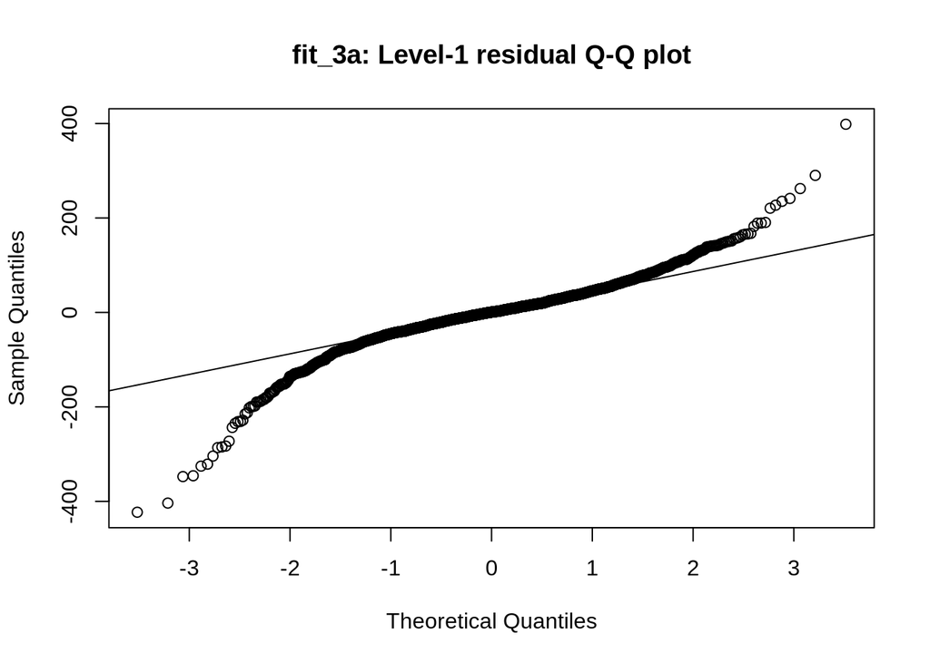

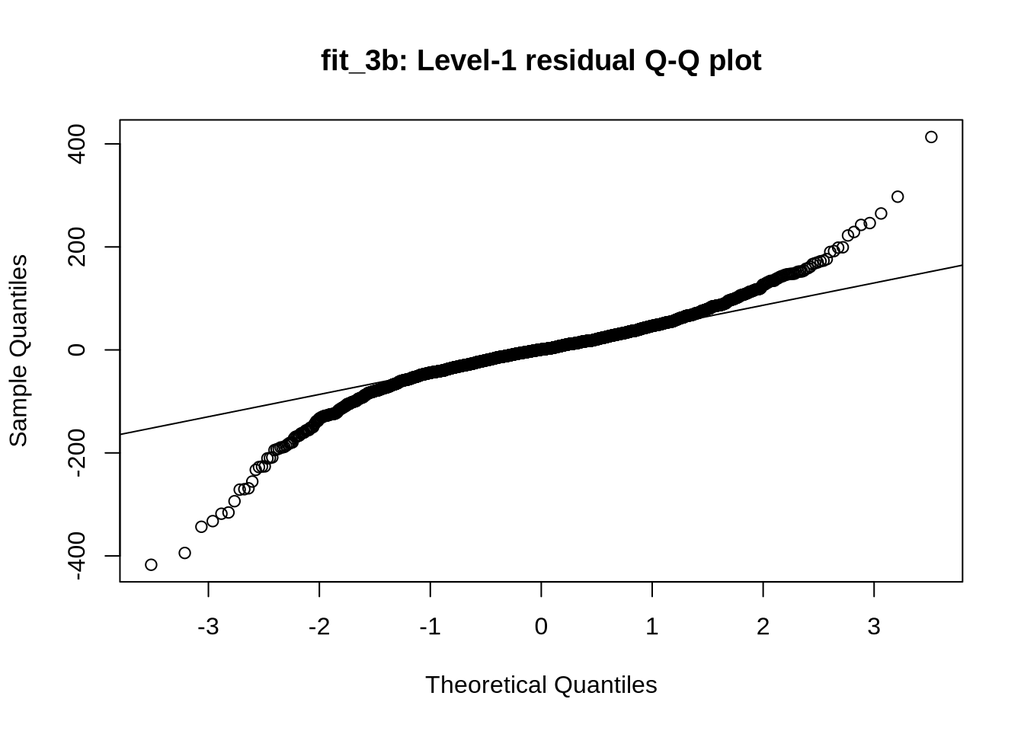